# Using the Moneyball Theory on the 2019-20 Chicago Bulls

Shaun Cameron

24/05/2020

# **Methods**

In this data analysis project the data was cleaned and separated into team data and player data respectively. In relation to the team data variables were run seperately against Wins to determine if there was a linear relationship between them. Upon this determination, relevant variables were run together using a multiple regression model, to determine the influence of the selected variables on Wins. This generated a team’s expected wins according to the regression model, which was then run against actual wins to determine model accuracy. Wins were chosen because it is the most absolute measure of success for a team.

In relation to the player data, the methodology was mostly the same. What differed was that instead of wins, the metric Wins Above Replacement was created and then used. 5 different regression models were then run, to simulate each position on the court, as it was likely that different positions value different aspects of gameplay. Upon reaching an adequate model which then plotted expected WAR against actual WAR, the top 10 players in each position were ranked based on their expected WAR, and then analysed on salary to determine which player in each position was the best value for money. WAR was chosen as the key metric because it reflects a players overall worth to his team, i.e. how many wins he contributes to his team when he is on court as opposed to a replacement level player (WAR = 0). Only players who played more than 29 games this season were considered eleigible for the analysis.

In the multiple regression models, the following assumptions were tested: Independence of Observations, linearity, outliers, influential points, points with high leverage, homoscedasticity, normality & multicollinearity.

# **Results**

## **Teams**

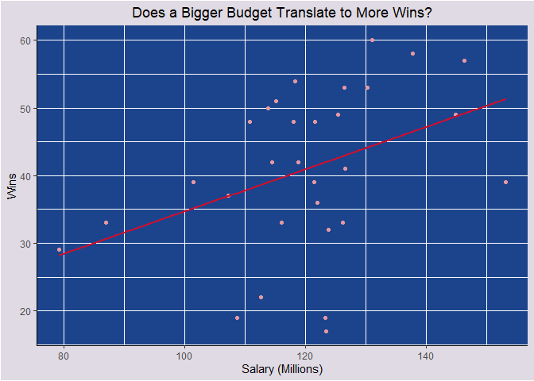

The above plot shows that more money does not necessarily equal more wins, which means that theoretically you can have a smaller budget and be as successful as teams with a bigger budget. This fits perfectly with the goal we are trying to achieve here.

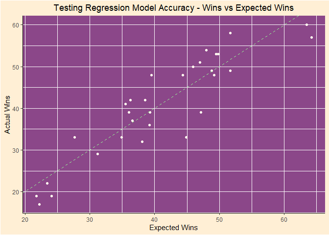

In the above plot the data points are pretty close to the regression line, indicating that the regression model was accurate enough to give good results.

## **Players**

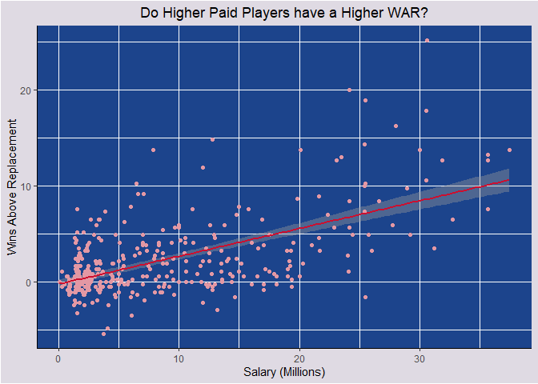

The plot indicates that while players with a higher salary generally have a higher WAR, players paid less can have a high WAR as well. This bodes well for the overall aim of this project, as the Bulls can get more value for money.

## Player Expected WAR

The following tables offer a snapshot of the most ideal players for our needs. Tm is the team the player plays for, sal_mil is the salary of the player in millions and XPWAR is the expected WAR value according to the regression model for the specific position.

### Centre Shortlist

| player_name | Tm | Age | sal_mil | XPWAR |
| --- | --- | --- | --- | --- |
| Nikola Jokic | DEN | 23 | 25.467 | 16.374 |
| Anthony Davis | NOP | 25 | 25.434 | 15.630 |
| Nikola Vucevic | ORL | 28 | 12.750 | 12.206 |
| Al Horford | BOS | 32 | 28.929 | 11.104 |
| Joel Embiid | PHI | 24 | 25.467 | 10.986 |
| Rudy Gobert | UTA | 26 | 23.492 | 9.853 |
| Karl-Anthony Towns | MIN | 23 | 7.839 | 9.804 |
| Marc Gasol | TOT | 34 | 24.119 | 9.361 |
| LaMarcus Aldridge | SAS | 33 | 22.347 | 8.095 |
| Clint Capela | HOU | 24 | 15.793 | 7.860 |

### Power Forward Shortlist

| player_name | Tm | Age | sal_mil | XPWAR |
| --- | --- | --- | --- | --- |
| Giannis Antetokounmpo | MIL | 24 | 24.157 | 15.402 |
| Joe Ingles | UTA | 31 | 12.545 | 9.007 |
| Blake Griffin | DET | 29 | 31.874 | 8.824 |
| Aaron Gordon | ORL | 23 | 21.591 | 7.046 |
| Gordon Hayward | BOS | 28 | 31.214 | 5.975 |
| Pascal Siakam | TOR | 24 | 1.545 | 5.837 |
| Tobias Harris | TOT | 26 | 14.800 | 5.828 |
| Thaddeus Young | IND | 30 | 13.764 | 5.096 |
| Julius Randle | NOP | 24 | 8.641 | 4.893 |
| Rudy Gay | SAS | 32 | 10.087 | 4.786 |

### Small Forward Shortlist

| player_name | Tm | Age | sal_mil | XPWAR |
| --- | --- | --- | --- | --- |
| LeBron James | LAL | 34 | 35.654 | 11.675 |
| Kawhi Leonard | TOR | 27 | 23.114 | 10.240 |
| Jimmy Butler | TOT | 29 | 19.842 | 7.974 |
| Danilo Gallinari | LAC | 30 | 21.588 | 5.692 |
| Otto Porter | TOT | 25 | 26.012 | 4.959 |
| Andre Iguodala | GSW | 35 | 16.000 | 4.356 |
| Khris Middleton | MIL | 27 | 13.000 | 4.169 |
| Bojan Bogdanovic | IND | 29 | 10.500 | 3.978 |
| Trevor Ariza | TOT | 33 | 15.000 | 3.882 |
| Jayson Tatum | BOS | 20 | 6.701 | 3.323 |

### Point Guard Shortlist

| player_name | Tm | Age | sal_mil | XPWAR |
| --- | --- | --- | --- | --- |
| James Harden | HOU | 29 | 30.570 | 17.293 |
| Stephen Curry | GSW | 30 | 37.457 | 14.669 |
| Russell Westbrook | OKC | 30 | 35.665 | 12.631 |
| Kemba Walker | CHO | 28 | 12.000 | 12.396 |
| Kyrie Irving | BOS | 26 | 20.099 | 12.144 |
| Damian Lillard | POR | 28 | 27.978 | 11.951 |
| Mike Conley | MEM | 31 | 30.521 | 9.983 |
| Ben Simmons | PHI | 22 | 6.435 | 9.339 |
| Eric Bledsoe | MIL | 29 | 15.000 | 8.047 |
| D’Angelo Russell | BRK | 22 | 7.020 | 7.621 |

### Shooting Guard Shortlist

| player_name | Tm | Age | sal_mil | XPWAR |
| --- | --- | --- | --- | --- |
| Jimmy Butler | TOT | 29 | 19.842 | 8.953 |
| Jrue Holiday | NOP | 28 | 26.641 | 8.543 |
| Bradley Beal | WAS | 25 | 25.434 | 7.374 |
| Luka Doncic | DAL | 19 | 6.569 | 6.217 |
| DeMar DeRozan | SAS | 29 | 27.740 | 5.680 |
| Malcolm Brogdon | MIL | 26 | 1.545 | 5.400 |
| Klay Thompson | GSW | 28 | 18.989 | 5.303 |
| Victor Oladipo | IND | 26 | 21.000 | 5.186 |
| Buddy Hield | SAC | 26 | 3.834 | 4.827 |
| CJ McCollum | POR | 27 | 25.760 | 4.386 |

# Recommendations

Although the team metric isn’t used to calculate expected wins for the Bulls next season, it did tell us some important things. It isn’t necessarily about scoring more points than your opponent. It’s about making the most of your opportunities when your team has the ball. If we ar efficient as a team we are more likely to win.

Assuming the starting 5 of all NBA teams play two thirds of the game, with the subs accounting for the other third, it seems fair that 66% of the available budget should go to negotiating for the starters. With the Chicago Bulls having a budget of $118 million, that allocates $78.67 million for the starters and $39.33 million for the bench. That theoretically gives us $15.73 million per starter to play with, although it’s ideal that we don’t use all of that.

Based on that, the following starters are proposed

**C:** Nikola Vucevic (Orlando Magic)

**PF:** Pascal Siakam (Toronto Raptors)

**SF:** Kawhi Leonard (Toronto Raptors)

**PG:** Ben Simmons (Philadelphia 76ers)

**SG:** Luka Doncic (Dallas Mavericks)

Together this proposed starting lineup has an expected WAR of 43.85 and uses up $50.42 million of the assigned starter budget, leaving the Bulls with $67.58 million to spend on bench players, draft pick signing bonuses and also for negotiating contract extensions.

Assuming that we use the rest of the money for bench players, that gives us an average of $6.76 million per bench player. Using the player data, it is approximated that 1 WAR is worth $3.83 million (total salaries paid to players divided by total player WAR). Theoretically that means that each bench player is calculated to be worth 1.76 WAR each. The average roster size of an NBA team is 15, meaning 10 bench players with a total WAR of 17.6.

If we put these numbers together, factoring in time on court and accounting for the estimation that a team full of replacement level players wins 23 games (per [paceandspacehoops.com](http://paceandspacehoops.com/how-much-value-do-g-league-replacement-players-have/)), the expected wins for next season can be calculated as follows:

(43.85 * 0.67) + (17.6 * 0.33) + 23 = 58

So the Bulls are expected to win 58 games using this model. If every other team has the same season they did in 2018-19, that would put the Bulls in 2nd place in the Eastern Conference Central division (behind Milwaukee). It would also land them in equal second place in the whole Eastern Conference, giving them either 2nd or 3rd seed in the playoffs.